# Nonlinear forecasting in pomp

Aaron A. King and Stephen P. Ellner

Licensed under the [Creative Commons attribution-noncommercial license](http://creativecommons.org/licenses/by-nc/3.0). Please share and remix noncommercially, mentioning its origin.

This document was produced using **pomp** version 1.19 and **R** version 3.5.3.

As a simple example we can use `nlf` to estimate the parameters `K` and `r` of the Gompertz model. An example of a minimal call, accepting the defaults for most arguments, is

```r
pompExample(gompertz)
fit <- nlf(
           gompertz,
           start=c(r=1,K=2,sigma=0.5,tau=0.5,X.0=1),
           transform=TRUE,
           est=c("K","r"),
           lags=c(1,2)
           )
```

where the first argument is the `pomp` object, `start` is a vector containing model parameters at which `nlf`’s search will begin, `est` contains the names of parameters `nlf` will estimate, and `lags` specifies which past values are to be used in the autoregressive model. In the call above `lags = c(1,2)` specifies that the autoregressive model predicts each observation, $y_t$ using $y_{t-1}$ and $y_{t-2}$, the two most recent past observations. The set of lags need not include the most recent observation, and skips are allowed, so that `lags=c(2,3,6)` is also “legal”.

The quasilikelihood is optimized numerically, so the reliability of the optimization should be assessed by doing multiple fits with different starting parameter values. Let us choose some starting values distributed about the true values of the parameters:

```r
starts <- parmat(coef(gompertz),5)
starts["K",] <- rlnorm(n=5,meanlog=log(coef(gompertz,"K")),sdlog=0.1)
starts["r",] <- rlnorm(n=5,meanlog=log(coef(gompertz,"r")),sdlog=0.1)
```

To make the results from different starts comparable, use the `seed` argument to initialize the random number generator the same way for each fit:

```r
foreach (start=iter(starts,by="column"),.combine=rbind) %dopar% {
    nlf(
        gompertz,
        start=start[,1],
        transform.data=log,
        transform=TRUE,
        est=c("K","r"),
        trace=4,
        lags=c(1,2),
        seed=7639873L,
        method="Nelder-Mead",
        skip.se=TRUE,
        nasymp=5000
    ) -> fit
    data.frame(as.list(coef(fit,c("r","K"))),value=logLik(fit))
} -> fits
```

The results in this case are very encouraging,

```r
fits
```

```
##           r        K    value
## 1 0.1121702 1.118515 40.33674
## 2 0.1121392 1.118507 40.33674
## 3 0.1121549 1.118517 40.33674
## 4 0.1121440 1.118490 40.33674
## 5 0.1121564 1.118561 40.33674
```

so below we will trust that repeated optimization isn’t needed.

The call above also used the `method` argument to specify that the Nelder-Mead option in `optim` is used to maximize the quasilikelihood. The `trace` argument is passed to `optim`; other arguments can be passed to `optim`, or the alternative optimizers, in the same way. `nasymp` sets the length of the Gompertz model simulation on which the quasilikelihood is based; larger values will give less variable parameter estimates, but will slow down the fitting process. The slowdown is dominated by the time required to generate the model simulations, so coding of `rprocess` using `Csnippet`s is a good idea.

The choice of lags affects the accuracy of the intermediate statistical model and therefore the accuracy of parameter estimates, so it is worth putting some effort into choosing good lags. Given enough time, a user could generate many artificial data sets, fit them all with several candidate lags, and evaluate the precision and accuracy of estimates. A quicker approach is to explore the shape and variability of the quasilikelihood function near pilot parameter estimates for several candidate sets of lags, using `nlf` with `eval.only=TRUE` to evaluate the quasilikelihood without performing optimization.

For the Gompertz model the complete state vector is observed, so it is plausible that forecasting based on the one most recent observation is optimal, i.e. `lags=1`. But because of measurement error, prediction based on multiple lags might be more accurate and more sensitive to parameter values, and longer-term forecasting might be beneficial if the effects of parameters are amplified over time. The plot below shows results for several candidate lags suggested by these considerations. To reduce Monte Carlo error in the objective function, we used `simulate` to create a very long “data set”:

```r
long.gomp <- simulate(gompertz,times=1:1000)
theta <- coef(long.gomp)
```

and then evaluated the quasilikelihood for a range of parameter values:

```r
lags <- list(1,2,c(1,2),c(2,3))
params <- sliceDesign(center=theta,
                      r=theta["r"]*exp(seq(-0.69,0.69,length=25)),
                      K=theta["K"]*exp(seq(-0.15,0.15,length=25)))
foreach (pars = iter(params,by="row"), .combine=rbind) %:%
  foreach (lag = lags, .combine=rbind) %dopar%
  {
    start <- unlist(subset(pars,select=-slice))
    fit <- nlf(long.gomp, start=start, nasymp=5000, lags=lag, eval.only=TRUE)
    data.frame(pars,lag=deparse(lag),lql=logLik(fit))
  } -> slices
```

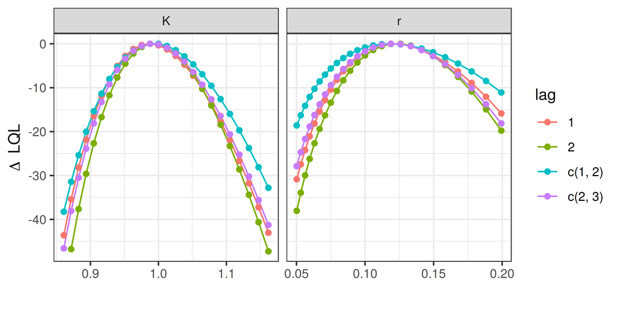

Based on the plot above, `lags = 2` seems like a good choice. Another consideration is the variability of parameter estimates on multiple short data sets:

```r
sims <- simulate(gompertz,times=1:60,nsim=100)
foreach (sim = sims, .combine=rbind) %:%
    foreach (lag = lags, .combine=cbind) %dopar%
    {
        fit <- nlf(sim, nasymp=5000, lags=lag, eval.only=TRUE)
        exp(logLik(fit)/60)
    } -> fvals
```

The last line above expresses the objective function as the geometric mean (quasi)likelihood per data point. The variability across data sets was nearly the same for all lags:

```r
apply(fvals,2,function(x)sd(x)/mean(x))
```

```
##  result.1  result.2  result.3  result.4
## 0.1491912 0.1486463 0.1462283 0.1530254
```

so we proceed to fit with `lags=2`.

```r
true.fit <- nlf(gompertz, transform=TRUE, est=c("K","r"), lags=2, seed=7639873,
                method="Nelder-Mead", nasymp=5000)
```

From `coef(true.fit)` and `true.fit$se` we get the estimates ($\pm$ 1 standard error) ${r}=0.11 \pm 0.062$ and ${K}=1.1\pm0.084$.

The standard errors provided by `nlf` are based on a Newey-West estimate of the variance-covariance matrix that is generally somewhat biased downward. More importantly, these rough-and-ready standard error estimates can be unstable. This is because they are obtained from finite differences of the NLF objective function. This function, in turn, is approximated using simulated time series of finite length, which typically gives rise to fine-scale wrinkles. Therefore, when time permits, bootstrap standard errors are preferable. When `nlf` is called with a non-NULL value of `bootsamp`, the quasilikelihood function is evaluated on the bootstrap sample of the time series specified in `bootsamp`. The first `max(lags)` observations cannot be forecast by the autoregressive model, so the size of the bootstrap sample is the length of the data series minus `max(lags)`:

```r
lags <- 2
nboot <- length(time(gompertz))-max(lags)
bootsamp <- replicate(n=100,sample(nboot,replace=TRUE))
foreach (j = seq_len(ncol(bootsamp)), .combine=rbind) %dopar% {
    fit <- nlf(
        gompertz,
        start=coef(gompertz),
        transform=TRUE,
        est=c("K","r"),
        lags=lags,
        seed=7639873,
        bootsamp=bootsamp[,j],
        skip.se=TRUE,
        method="Nelder-Mead",
        trace=4,
        nasymp=5000
    )
    coef(fit,c("r","K"))
}
```

[output not shown]

```r
apply(pars,2,sd)
```

```
##          r          K
## 0.04256981 0.07166552
```

In this case, the bootstrap standard errors don’t differ much from the Newey-West estimates.

```r
lags <- 2
nboot <- length(obs(gompertz))-max(lags)
bootsamp <- replicate(100,sample(nboot-2,size=floor(nboot/3),replace=TRUE))
bootsamp <- rbind(bootsamp,bootsamp+1,bootsamp+2)
```

and otherwise proceed exactly as above.

```r
foreach (j = seq_len(ncol(bootsamp)), .combine=rbind) %dopar% {
    fit <- nlf(
        gompertz,
        transform=TRUE,
        est=c("K","r"),
        lags=lags,
        seed=7639873L,
        bootsamp=bootsamp[,j],
        skip.se=TRUE,
        method="Nelder-Mead",
        trace=4,
        nasymp=5000
    )
    coef(fit,c("r","K"))
} -> pars
```

```r
apply(pars,2,sd)
```

```
##          r          K
## 0.04512804 0.08930814
```

## References

Ellner, S. P., B. A. Bailey, G. V. Bobashev, A. R. Gallant, B. T. Grenfell, and D. W. Nychka. 1998. Noise and nonlinearity in measles epidemics: Combining mechanistic and statistical approaches to population modeling. American Naturalist 151:425–440.

Gouriéroux, C., and A. Monfort. 1997. Simulation-based econometric methods. Oxford University Press, Oxford.

Kendall, B. E., C. J. Briggs, W. W. Murdoch, P. Turchin, S. P. Ellner, E. McCauley, R. M. Nisbet, and S. N. Wood. 1999. Why do populations cycle? A synthesis of statistical and mechanistic modeling approaches. Ecology 80:1789–1805.

Kendall, B. E., S. P. Ellner, E. McCauley, S. N. Wood, C. J. Briggs, W. M. Murdoch, and P. Turchin. 2005. Population cycles in the pine looper moth: Dynamical tests of mechanistic hypotheses. Ecological Monographs 75:259–276.

Smith, A. A. 1993. Estimating nonlinear time-series models using simulated vector autoregression. Journal of Applied Econometrics 8:S63–S84.

Tidd, C. W., L. F. Olsen, and W. M. Schaffer. 1993. The case for chaos in childhood epidemics. II. predicting historical epidemics from mathematical models. Proceedings of the Royal Society of London, Series B 254:257–273.